# RNA-seq analysis in R

Differential Expression of RNA-seq data

Mark Dunning

Last modified: 08 Jul 2018

**Original Authors: Belinda Phipson, Anna Trigos, Matt Ritchie, Maria Doyle, Harriet Dashnow, Charity Law**, **Stephane Ballereau, Oscar Rueda, Ashley Sawle** Based on the course [RNAseq analysis in R](http://combine-australia.github.io/2016-05-11-RNAseq/) delivered on May 11/12th 2016 and modified by Cancer Research Uk Cambridge Centre for the [Functional Genomics Autumn School 2017](https://bioinformatics-core-shared-training.github.io/cruk-autumn-school-2017/)

## Resources and data files

This material has been created using the following resources:  
http://www.statsci.org/smyth/pubs/QLedgeRPreprint.pdf (Lun, Chen, and Smyth 2016)  
http://monashbioinformaticsplatform.github.io/RNAseq-DE-analysis-with-R/99-RNAseq_DE_analysis_with_R.html  
http://bioconductor.org/packages/devel/bioc/vignettes/DESeq2/inst/doc/DESeq2.html

Data files downloaded from:  
ftp://ftp.ncbi.nlm.nih.gov/geo/series/GSE60nnn/GSE60450/suppl/GSE60450_Lactation-GenewiseCounts.txt.gz http://bioinf.wehi.edu.au/software/MSigDB/mouse_c2_v5.rdata http://bioinf.wehi.edu.au/software/MSigDB/mouse_H_v5.rdata

Data files:  
sampleinfo.txt  
GSE60450_Lactation-GenewiseCounts.txt  
mouse_c2_v5.rdata  
mouse_H_v5.rdata

Data files available from: https://figshare.com/s/1d788fd384d33e913a2a You should download these files and place them in your `/data` directory.

## Differential expression with `DESeq2`

Now that we are happy that we have normalised the data and that the quality looks good, we can continue to testing for differentially expressed genes. There are a number of packages to analyse RNA-Seq data. Most people use `DESeq2` or `edgeR`. We will use `DESeq2` for the rest of this practical.

**First make sure we have all the objects and libraries loaded*

```r
library(DESeq2)
library(edgeR)
```

### Recap of pre-processing

The previous section walked-through the pre-processing and transformation of the count data. Here, for completeness, we list the minimal steps required to process the data prior to differential expression analysis.

```r
library(DESeq2)
library(edgeR)
## Read the counts from the downloaded data
seqdata <- read.delim("data/GSE60450_Lactation-GenewiseCounts.txt", stringsAsFactors = FALSE)
#
# Remove first two columns from seqdata

countdata <- seqdata[,-(1:2)]

# Store EntrezGeneID as rownames
rownames(countdata) <- seqdata[,1]
countdata
colnames(countdata) <- substr(colnames(countdata), 1, 7)
countdata
## Calculate the Counts Per Million measure
myCPM <- cpm(countdata)
## Identify genes with at least 0.5 cpm in at least 2 samples
thresh <- myCPM > 0.5
keep <- rowSums(thresh) >= 2
# Subset the rows of countdata to keep the more highly expressed genes
counts.keep <- countdata[keep,]
## Convert to an edgeR object
sampleinfo <- read.delim("data/SampleInfo_Corrected.txt")

dds <- DESeqDataSetFromMatrix(counts.keep,
                              colData = sampleinfo,
                              design = ~CellType)
```

We also have the output of the pre-processing section saved as an R object if you didn’t manage to complete these steps.

```r
## Only run if you didn't complete the previous section on pre-processing
load("Robjects/preprocessing.Rdata")
```

### Overview of testing

As we saw in the R introduction, there are many options for performing a test to assess the significance of data from different sample groups. Taking a toy example:-

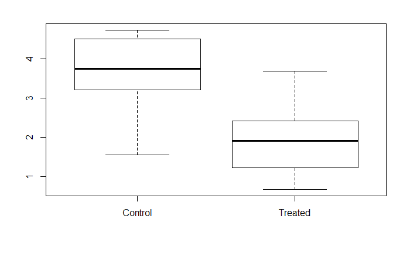

```r
gene_counts <- c(rnorm(10,mean = 2,sd=1),
                 rnorm(10, mean=4,sd=1))
group <- c(rep("Treated",10),
           rep("Control",10))
boxplot(gene_counts ~ group)
```

However, we cannot naively apply such a test to RNA-seq data that are *count-based*. Much work in the microarray era was carried out on statistical analysis of gene expression data with the most-popular approach being that of the limma Bioconductor package. This package has been cited thousands of time and applies a *linear model* approach to the analysis of gene expression data. The [user guide](https://www.bioconductor.org/packages/devel/bioc/vignettes/limma/inst/doc/usersguide.pdf) is extensive and has many examples of applying linear model design to expression data. It is even possible to use limma on RNA-seq data provided that the data are [appropriately transformed](https://genomebiology.biomedcentral.com/articles/10.1186/gb-2014-15-2-r29).

For this workflow we are going to use `DESeq2` which uses a negative binomial distribution to model the data.

### Differential Expression with DESeq2

In `DESeq2`, a differential expression analysis can be performed by using the `DESeq` function. This function requires a single parameter which is the `DESeqDataSet` object generated in the pre-processing steps describes. We have previously defined the test condition using the `design` argument when we created the object. This can be checked using the `design` function.

The function runs a couple of processing steps automatically to adjust for different library size and gene-wise variabiliy, which you can read about in the [DESeq2 vignette)[http://bioconductor.org/packages/devel/bioc/vignettes/DESeq2/inst/doc/DESeq2.html#the-deseq2-model].

```r
colData(dds)
```

```
DataFrame with 12 rows and 4 columns
                                 FileName SampleName CellType   Status
                                 <factor>   <factor> <factor> <factor>
MCL1.DG MCL1.DG_BC2CTUACXX_ACTTGA_L002_R1    MCL1.DG    basal   virgin
MCL1.DH MCL1.DH_BC2CTUACXX_CAGATC_L002_R1    MCL1.DH    basal   virgin
MCL1.DI MCL1.DI_BC2CTUACXX_ACAGTG_L002_R1    MCL1.DI    basal pregnant
MCL1.DJ MCL1.DJ_BC2CTUACXX_CGATGT_L002_R1    MCL1.DJ    basal pregnant
MCL1.DK MCL1.DK_BC2CTUACXX_TTAGGC_L002_R1    MCL1.DK    basal  lactate
...                                   ...        ...      ...      ...
MCL1.LB MCL1.LB_BC2CTUACXX_TGACCA_L001_R1    MCL1.LB  luminal   virgin
MCL1.LC MCL1.LC_BC2CTUACXX_GCCAAT_L001_R1    MCL1.LC  luminal pregnant
MCL1.LD MCL1.LD_BC2CTUACXX_GGCTAC_L001_R1    MCL1.LD  luminal pregnant
MCL1.LE MCL1.LE_BC2CTUACXX_TAGCTT_L001_R1    MCL1.LE  luminal  lactate
MCL1.LF MCL1.LF_BC2CTUACXX_CTTGTA_L001_R1    MCL1.LF  luminal  lactate
```

```r
design(dds)
```

```
~CellType
```

```r
de <- DESeq(dds)
```

Typically we decide the design for the analysis when we create the DESeq2 objects, but it can be modified prior to the differential expression analysis

```r
design(dds) <- ~CellType
```

The results of the analysis can be obtained using the `results` function and displayed to the screen. Each row is a particular gene measured in the study (i.e. all genes in the organism being studies) and each column reports some aspect of the differential expression analysis for that gene. Note that all genes are reported. Not all genes will be statistically significant. At this stage the gene identifiers are not very informative, something we will fix in the next section. We also cannot easily identify genes that are differentially expressed.

```r
de <- DESeq(dds)
results.cellType <- as.data.frame(results(de))
results.cellType
```

|  | baseMean | log2FoldChange | lfcSE | stat | pvalue | padj |
| --- | --- | --- | --- | --- | --- | --- |
| 497097 | 126.520540 | -1.027743e+01 | 0.95724117 | -10.736514777 | 6.858483e-27 | 1.534707e-25 |
| 20671 | 50.632412 | -2.702536e+00 | 0.36710571 | -7.361736498 | 1.815330e-13 | 1.523836e-12 |
| 27395 | 359.056774 | 8.069908e-01 | 0.17490259 | 4.613944504 | 3.950980e-06 | 1.305534e-05 |
| 18777 | 744.995527 | 8.047792e-02 | 0.23135933 | 0.347848177 | 7.279542e-01 | 7.718247e-01 |
| 21399 | 1098.710100 | -3.585758e-01 | 0.08918784 | -4.020456158 | 5.808556e-05 | 1.567001e-04 |
| 58175 | 45.891983 | 4.435551e+00 | 0.57031655 | 7.777348925 | 7.406013e-15 | 7.073772e-14 |
| 108664 | 1258.204043 | 1.031520e+00 | 0.24544737 | 4.202612663 | 2.638519e-05 | 7.588443e-05 |
| 12421 | 1199.209450 | -9.859456e-02 | 0.18617285 | -0.529586111 | 5.963989e-01 | 6.530748e-01 |
| 319263 | 1470.341408 | 8.939875e-03 | 0.36460602 | 0.024519275 | 9.804384e-01 | 9.846768e-01 |
| 59014 | 1055.987109 | -5.275057e-01 | 0.27574904 | -1.912992083 | 5.574907e-02 | 8.216473e-02 |

[output cut: 990 more lines]